# tp2

GroupeB

2025-04-26

## Introduction :

Dans un contexte où les menaces informatiques se multiplient et évoluent rapidement, les centres d’opérations de sécurité (SOC) doivent être en mesure de détecter, classifier et répondre efficacement aux incidents de cybersécurité. Pour renforcer ces capacités, Microsoft a développé la base de données GUIDE, la plus vaste collection publique d’incidents réels de sécurité à ce jour. Mise en place dans le cadre du développement du Copilot for Security Guided Response (CGR), cette base vise à améliorer l’enquête, le triage et l’assainissement des incidents de sécurité.

L’analyse de cette base de données permet de dégager des tendances et des modèles susceptibles d’aider les analystes SOC à prioriser les alertes et à identifier les menaces les plus critiques. Dans ce projet, nous proposons d’explorer plusieurs hypothèses statistiques afin de mieux comprendre les facteurs associés aux niveaux de risque et aux verdicts finaux attribués aux incidents.

Les hypothèses principales testées sont les suivantes :

**Problème rencontré :** La base de donnée fournie a **4147992** observations et 46 variables, soit 45 potentielles variables explicatives. Ceci a soulevé deux problèmes majeurs dans le cadre de notre travail :

**Problème1** : Le fichier est trop lourd ; il pèse plus d’un GigaOctet, ce qui ralentit les algorithmes de Machine learning, puisque nous n’avons pas accès aux super-calculateurs. Pour contourner cet obstacle, nous avons selectionné un échantillon de 25 000 observations que nous avons renommé df. Tout notre travail est basé sur cette nouvelle database. Mais l’exécution final s’est faite sur la BD originale

**Problème2** : En présence d’autant de variables cibles et d’autant d’observations, il y a un risque de surapprentissage. Donc nous allons préter une attention particulière à la colinéarité entre les différentes variables. Et via une analyse par composantes principales, on pourra selectionner les prédicteurs les plus pertinents.

### 0. Méthodologie :

1. Prétraitement des données :

   1.1 importation et source des données (À propos de l’auteur) ;

   1.2 Description des variables ;
   - Variable cible,
   - Variables explicatives

   1.3 Nettoyage de la base des donnée ;

2.Analyse exploratoire des données :

```
2.1 Visualisations : Diagrammes de comparaison

  * Les diagramme en barres ;

  * Histogrammes ;

  * Séries temporelles.
```

2.2 Test d’hypothèse

2.3 Apprentisssage non supervisé sur un échantillon alléeatoire.

```
2.3.1 Analyse par composantes principales

2.3.2 Clustering : Méthode des k-means
```

3. Modélisation prédictive.

   3.1 Régression logistique :

   * Choix du meilleur modèle par validation croisée
   ```

   3.2 Arbres de décision

   ```
   * Construction d'un arbre de décision

   * Élagage de l'arbre et choix des paramètre par validation croisée
   ```

4. Mise en production
5. Conclusion :

5.1 Quelques recommandations basées sur l’étude

5.2 Pour aller plus loin

### 1. Prétraitement des données

#### 1.1 À propos de l’auteur ;

Cette base de données est accessible en libre téléchargement via kagle(https://www.kaggle.com/datasets/Microsoft/microsoft-security-incident-prediction?select=GUIDE_Train.csv).

Les auteurs sont :

*Microsoft (Propriétaire)*

*Scott Freitas (Administrateur)*

*amirh gharib (Editeur)*

*Rob McCann (Editeur)*

*Jovan Kalajdjieski (Editeur).*

cette base englobe plus de 13 millions d’éléments de preuve sur 33 types d’entités, dont 1,6 million d’alertes et 1 million d’incidents annotés avec des étiquettes de triage provenant de clients sur une période de deux semaines. Cette télémétrie a été collectée auprès des clients Microsoft Defender XDR, englobant divers produits tels que des terminaux, des périphériques réseau, des environnements cloud, des systèmes de messagerie, etc. (pris dans le site de l’auteur)

#### 1.2 Description des variables :

##### **La Variable cible** : IncidentGrade : (La gravité de l’incident).

Cette variables va nous aider à identifier la gravité des différents incidents.

##### **Variables explicatives potentielles** :

**Id** : Identifiant unique pour chaque paire OrgId-IncidentId.

**OrgId** : Identifiant de l’organisation.

**IncidentId** : Identifiant unique de l’incident au sein de l’organisation.

**AlertId** : Identifiant unique pour une alerte.

**Timestamp** : Date et heure de création de l’alerte.

**DetectorId** : Identifiant unique du détecteur ayant généré l’alerte.

**AlertTitle** : Titre de l’alerte.

**Category** : Catégorie de l’alerte.

**MitreTechniques** : techniques d’attaque qui ont été identifiées dans une alerte de sécurité, basées sur le framework MITRE ATT&CK.

**IncidentGrade** : Niveau de gravité attribué à l’incident par le SOC.

**ActionGrouped** : Action de remédiation de l’alerte par le SOC (niveau général).

**ActionGranular** : Action de remédiation de l’alerte par le SOC (niveau détaillé).

**EntityType** : Type d’entité impliquée dans l’alerte.

**EvidenceRole** : Rôle de la preuve dans l’enquête.

**DeviceId** : Identifiant unique du dispositif.

**Sha256** : Empreinte SHA-256 du fichier.

**IpAddress** : Adresse IP impliquée.

**Url** : URL impliquée.

**AccountSid** : Identifiant du compte on-premises.

**AccountUpn** : Identifiant du compte email.

**AccountObjectId** : Identifiant du compte Entra ID.

**AccountName** : Nom du compte on-premises.

**DeviceName** : Nom du dispositif.

**NetworkMessageId** : Identifiant au niveau organisationnel pour le message email.

**EmailClusterId** : Identifiant unique du cluster d’emails.

**RegistryKey** : Clé de registre impliquée.

**RegistryValueName** : Nom de la valeur du registre.

**RegistryValueData** : Données de la valeur du registre.

**ApplicationId** : Identifiant unique de l’application.

**ApplicationName** : Nom de l’application.

**OAuthApplicationId** : Identifiant de l’application OAuth.

**ThreatFamily** : Famille de logiciels malveillants associée à un fichier.

**FileName** : Nom du fichier.

**FolderPath** : Chemin du dossier contenant le fichier.

**ResourceIdName** : Nom de la ressource Azure.

**ResourceType** : Type de ressource Azure.

**Roles** : Métadonnées supplémentaires sur le rôle de la preuve dans l’alerte.

**OSFamily** : Famille du système d’exploitation.

**OSVersion** : Version du système d’exploitation.

**AntispamDirection** : Direction du filtre antispam.

**SuspicionLevel** : Niveau de suspicion.

**LastVerdict** : Verdict final de l’analyse de la menace.

**CountryCode** : Code du pays où la preuve a été trouvée.

**State** : État où la preuve a été trouvée.

**City** : Ville où la preuve a été trouvée.

Les variables sont réparties en 31 numériques et 15 catégorielles.

En réalité,les variables numérique sont en fait des id et des codes . ==> ce sont des variables catégorique à proprement parler. On devra modifier le type dans les traitements.

Nous constatons qu’il ya beaucoup de colonnes qui doivent être supprimées par ce que Ce sont des Id –> Elles sont facilement identifiablesde façon unique et donc, non performants pour les algorithmes d’apprentissage machine ;

##### **Supression des colonnes non pertinentes pour l’étude**

```r
col_a_supprimer = c("Id", "OrgId" ,"IncidentId","AlertId","DetectorId" ,
                    "DeviceId","AccountSid","AccountObjectId",
                    "NetworkMessageId","EmailClusterId","ApplicationId",
                    "OAuthApplicationId","ResourceIdName")
for (colonne in col_a_supprimer){
  df[[colonne]] <- NULL
}
```

Bien qu’elles sont des identifiant des données,

- Les variables “AccountUpn” et “AccountName” sont conservées par ce que, bien qu’étant des failles d’identification, elles rapportent des analyses sur les comptes utilisateurs,ce qui pourrait permettre de comprendre la fraude.
- “DeviceName” a été conservé pour effectuer une analyse sur les attaques récurrentes sur certains appareils.
- On conserve “FileName” et “Sha256” pour tenir compte des fichiers malveillants récurrents.

```r
valeurs_manquantes <- colSums(is.na(df))
pourcentage_nan <- (valeurs_manquantes / nrow(df)) * 100
valeurs_manquantes <- data.frame(
  Column = names(valeurs_manquantes),
  Missing_Values = valeurs_manquantes,
  Pourcentage_NaN = pourcentage_nan
) %>%
  filter(Pourcentage_NaN != 0) %>%
  arrange(desc(Pourcentage_NaN))
print(valeurs_manquantes)
```

```
##                              Column Missing_Values Pourcentage_NaN
## ActionGrouped         ActionGrouped          24991          99.964
## ActionGranular       ActionGranular          24991          99.964
## ResourceType           ResourceType          24973          99.892
## ThreatFamily           ThreatFamily          24804          99.216
## AntispamDirection AntispamDirection          24571          98.284
## Roles                         Roles          24318          97.272
## SuspicionLevel       SuspicionLevel          21140          84.560
## LastVerdict             LastVerdict          19131          76.524
## MitreTechniques     MitreTechniques          13955          55.820
```

- On va supprimer les colonnes “ActionGrouped”, “ActionGranular”, “ResourceType”, “ThreatFamily”,“AntispamDirection”, “Roles”

Dans la colonne *‘SuspicionLevel’* , la valeur manquante signifie que la transaction est non suspecte ou non évaluée.

La valeur manquante dans la colone *‘LastVerdict’* signifie qu’il n’y a pas encore de verdict, ou que le verdict est inconnu

Dans la colonne *‘MitreTechniques’* On va remplacer les valeurs manquantes par “Unknown”

```r
skim(df) %>%
  kable()
```

| skim_type | skim_variable | n_missing | complete_rate | character.min | character.max | character.empty | character.n_unique | character.whitespace | numeric.mean | numeric.sd | numeric.p0 | numeric.p25 | numeric.p50 | numeric.p75 | numeric.p100 | numeric.hist |
| --- | --- | --- | --- | --- | --- | --- | --- | --- | --- | --- | --- | --- | --- | --- | --- | --- |
| character | Timestamp | 0 | 1 | 24 | 24 | 0 | 21661 | 0 | NA | NA | NA | NA | NA | NA | NA | NA |
| character | Category | 0 | 1 | 6 | 19 | 0 | 18 | 0 | NA | NA | NA | NA | NA | NA | NA | NA |
| character | MitreTechniques | 0 | 1 | 5 | 85 | 0 | 273 | 0 | NA | NA | NA | NA | NA | NA | NA | NA |
| character | IncidentGrade | 0 | 1 | 12 | 14 | 0 | 3 | 0 | NA | NA | NA | NA | NA | NA | NA | NA |
| character | EntityType | 0 | 1 | 2 | 20 | 0 | 23 | 0 | NA | NA | NA | NA | NA | NA | NA | NA |
| character | EvidenceRole | 0 | 1 | 7 | 8 | 0 | 2 | 0 | NA | NA | NA | NA | NA | NA | NA | NA |
| character | SuspicionLevel | 0 | 1 | 10 | 14 | 0 | 3 | 0 | NA | NA | NA | NA | NA | NA | NA | NA |
| character | LastVerdict | 0 | 1 | 9 | 50 | 0 | 5 | 0 | NA | NA | NA | NA | NA | NA | NA | NA |
| character | Usage | 0 | 1 | 6 | 7 | 0 | 2 | 0 | NA | NA | NA | NA | NA | NA | NA | NA |
| numeric | AlertTitle | 0 | 1 | NA | NA | NA | NA | NA | 2436.29748 | 1.023457e+04 | 0 | 2.0 | 9 | 114 | 113030 | ▇▁▁▁▁ |
| numeric | Sha256 | 0 | 1 | NA | NA | NA | NA | NA | 128420.68796 | 3.446332e+04 | 0 | 138268.0 | 138268 | 138268 | 138268 | ▁▁▁▁▇ |
| numeric | IpAddress | 0 | 1 | NA | NA | NA | NA | NA | 286243.16604 | 1.408837e+05 | 0 | 360606.0 | 360606 | 360606 | 360606 | ▂▁▁▁▇ |
| numeric | Url | 0 | 1 | NA | NA | NA | NA | NA | 150625.54384 | 3.695025e+04 | 0 | 160396.0 | 160396 | 160396 | 160396 | ▁▁▁▁▇ |
| numeric | AccountUpn | 0 | 1 | NA | NA | NA | NA | NA | 473241.35820 | 2.876853e+05 | 0 | 106543.8 | 673934 | 673934 | 673934 | ▃▁▁▁▇ |
| numeric | AccountName | 0 | 1 | NA | NA | NA | NA | NA | 358497.64484 | 1.737508e+05 | 0 | 453297.0 | 453297 | 453297 | 453297 | ▂▁▁▁▇ |
| numeric | DeviceName | 0 | 1 | NA | NA | NA | NA | NA | 141456.44836 | 3.914793e+04 | 0 | 153085.0 | 153085 | 153085 | 153085 | ▁▁▁▁▇ |
| numeric | RegistryKey | 0 | 1 | NA | NA | NA | NA | NA | 1627.95284 | 6.921206e+01 | 0 | 1631.0 | 1631 | 1631 | 1631 | ▁▁▁▁▇ |
| numeric | RegistryValueName | 0 | 1 | NA | NA | NA | NA | NA | 634.55696 | 1.652424e+01 | 0 | 635.0 | 635 | 635 | 635 | ▁▁▁▁▇ |
| numeric | RegistryValueData | 0 | 1 | NA | NA | NA | NA | NA | 859.31928 | 2.365870e+01 | 0 | 860.0 | 860 | 860 | 860 | ▁▁▁▁▇ |
| numeric | ApplicationName | 0 | 1 | NA | NA | NA | NA | NA | 3336.61984 | 5.293501e+02 | 0 | 3421.0 | 3421 | 3421 | 3421 | ▁▁▁▁▇ |
| numeric | FileName | 0 | 1 | NA | NA | NA | NA | NA | 261989.66588 | 8.188976e+04 | 0 | 289573.0 | 289573 | 289573 | 289573 | ▁▁▁▁▇ |
| numeric | FolderPath | 0 | 1 | NA | NA | NA | NA | NA | 107448.03684 | 3.251334e+04 | 0 | 117668.0 | 117668 | 117668 | 117668 | ▁▁▁▁▇ |
| numeric | OSFamily | 0 | 1 | NA | NA | NA | NA | NA | 4.90132 | 6.942057e-01 | 0 | 5.0 | 5 | 5 | 5 | ▁▁▁▁▇ |
| numeric | OSVersion | 0 | 1 | NA | NA | NA | NA | NA | 64.69488 | 9.178110e+00 | 0 | 66.0 | 66 | 66 | 66 | ▁▁▁▁▇ |
| numeric | CountryCode | 0 | 1 | NA | NA | NA | NA | NA | 221.99624 | 6.535101e+01 | 0 | 242.0 | 242 | 242 | 242 | ▁▁▁▁▇ |
| numeric | State | 0 | 1 | NA | NA | NA | NA | NA | 1341.76372 | 3.671462e+02 | 0 | 1445.0 | 1445 | 1445 | 1445 | ▁▁▁▁▇ |
| numeric | City | 0 | 1 | NA | NA | NA | NA | NA | 9863.70668 | 2.727679e+03 | 0 | 10630.0 | 10630 | 10630 | 10630 | ▁▁▁▁▇ |

Plusieurs colonnes ne sont pas dans le bon type, on va les transformer. Notons déjà que dans notre situation particulière, toutes les colonnes numériques devraient etre categorielles

### 2.Analyse exploratoire des données :

#### 2.1 Visualisations : Diagrammes de comparaison

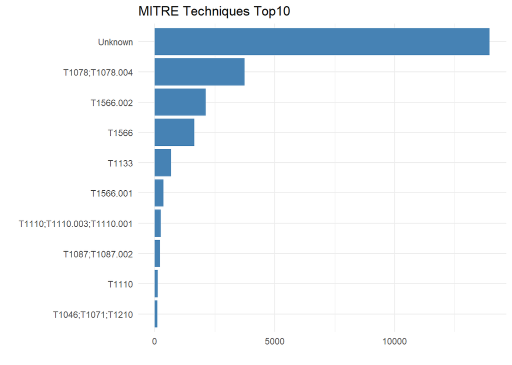

```r
technique_counts <- df %>%
  group_by(MitreTechniques) %>%
  summarise(Count = n())

techniques_ordone <- technique_counts %>%
  arrange(desc(Count))

ggplot(data = head(techniques_ordone, 10),
       aes(y = fct_reorder(MitreTechniques, Count), x = Count)) +
  geom_bar(stat = "identity", fill = "steelblue") +
  labs(
    title = "MITRE Techniques Top10",
    x= " ",
    y  = " "
  ) +
  theme_minimal()
```

**interprétation** :

La majorité des alertes sont associées à «Unknown» , ce qui signifie qu’on n’est pas capable de répérer la source et les méthodes de plusiers attaques. On devrait renforcer davantage la cibersécurité et former les employés, ou recruter des spécialistes.

Les techniques T1078, T1566, et T1133 sont les plus courantes après “Unknown”, ce qui suggère que ces méthodes sont des vecteurs d’attaque privilégiés.

Certaines attaques combinent plusieurs techniques , ce qui signifie qu’un modèle de détection efficace doit prendre en compte les relations entre ces différentes méthodes .

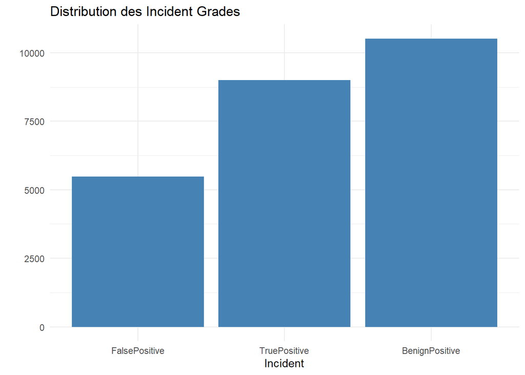

```r
IncidentGrade_count <- df %>%
  group_by(IncidentGrade) %>%
  summarise(Count = n())

ggplot(data = IncidentGrade_count,
       aes(x = fct_reorder(IncidentGrade, Count), y = Count)) +
  geom_bar(stat = "identity", fill = "steelblue") +
  labs(
    title = "Distribution des Incident Grades",
    x = "Incident",
    y = " "
  ) +
  theme_minimal()
```

**Interpretation** : Le nombre élevé de BenignPositive et FalsePositive indique que le système génère beaucoup d’alertes inutiles (bruit).Ce qui est contre productif. Une première recommandation est déjà de rafinner et d’améliorer le système d’alerte pour qu’il capte moin de bruit.

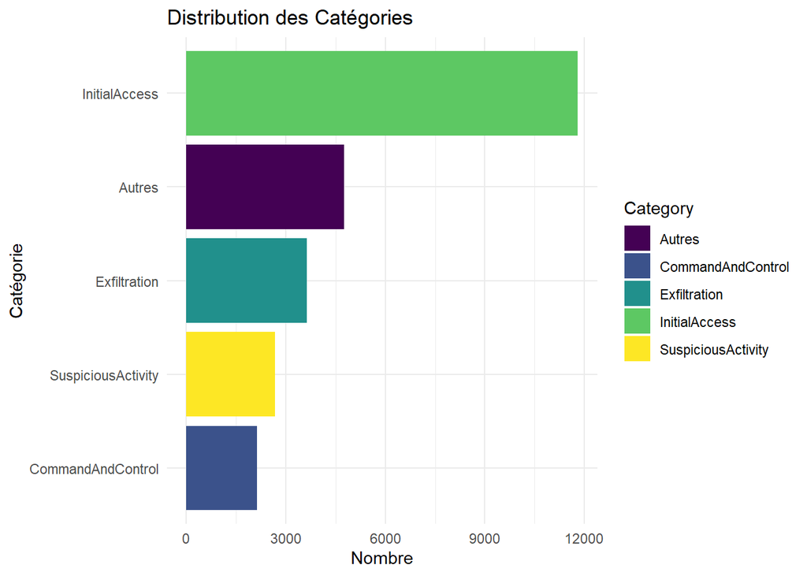

```r
category_counts <- df %>%
  count(Category, name = "Count") %>%
  arrange(desc(Count))

top_4_categories <- category_counts %>%
  head(4)


autres_count <- sum(category_counts$Count) - sum(top_4_categories$Count)

top_5_categories <- top_4_categories %>%
  add_row(Category = "Autres", Count = autres_count)


ggplot(top_5_categories, aes(x = fct_reorder(Category, Count), y = Count, fill = Category)) +
  geom_bar(stat = "identity") +
  coord_flip() +  # Met les barres à l'horizontale
  labs(title = "Distribution des Catégories", x = "Catégorie", y = "Nombre") +
  theme_minimal() +
  scale_fill_viridis_d()
```

**interpretation** :

*Initial Access*est la catégorie la plus fréquente Cela signifie que la majorité des alertes concernent des tentatives d’accès initiales (ex. hameçonnage, exploitation de vulnérabilités).

*Exfiltration*arrive en deuxième position Cela correspond aux tentatives de vol de données en dehors du réseau cible ce qui indique aussi que des attaquants ont réussi à pénétrer les systèmes et tenter d’exfiltrer des informations sensibles.

*Autres* cette catégorie regroupe toutes les autres catégories moins fréquentes.

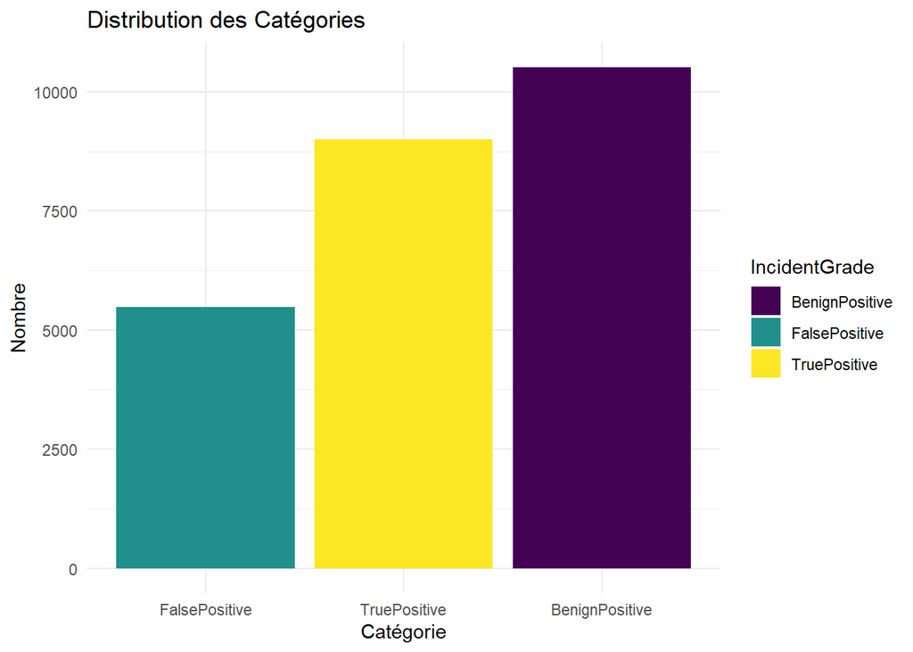

```r
incident_counts <- df %>%
  count(IncidentGrade, name = "Count")

ggplot(incident_counts, aes(x = fct_reorder(IncidentGrade, Count), y = Count, fill = IncidentGrade)) +
  geom_bar(stat = "identity") +
  #coord_flip() +  # Met les barres à l'horizontale
  labs(title = "Distribution des Catégories", x = "Catégorie", y = "Nombre") +
  theme_minimal() +
  scale_fill_viridis_d()
```

**interpretation**

*BenignPositive*(Majoritaire) représente une grande partie du graphique. Ce qui signifie que le système présent capture énormément de fausses alertes.

*TruePositive* (Proportion élevée) indique que le système de détection a bien identifié de véritables incidents qui sont des alertes valides et confirmées comme étant des menaces . Une proportion élevée de TruePositiveest un bon signe car cela signifie que la détection est efficace.

*FalsePositive* (Moins fréquents) ce sont des alertes générées à tort. Une proportion trop élevée de FalsePositive peut poser problème , car cela signifie que l’algorithme génère trop d’alertes inutiles , ce qui peut surcharger les analystes et réduire la confiance dans le système.

**Puisque nous voulons faire une regression logistique pour prédire la variable ‘IncidentGrade’, nous allons modifier cette dernière pour obtenir juste deux classes de la façon suivante :**

BenignPositive –> negatif

FalsePositive –> negatif

TruePositive –> positif

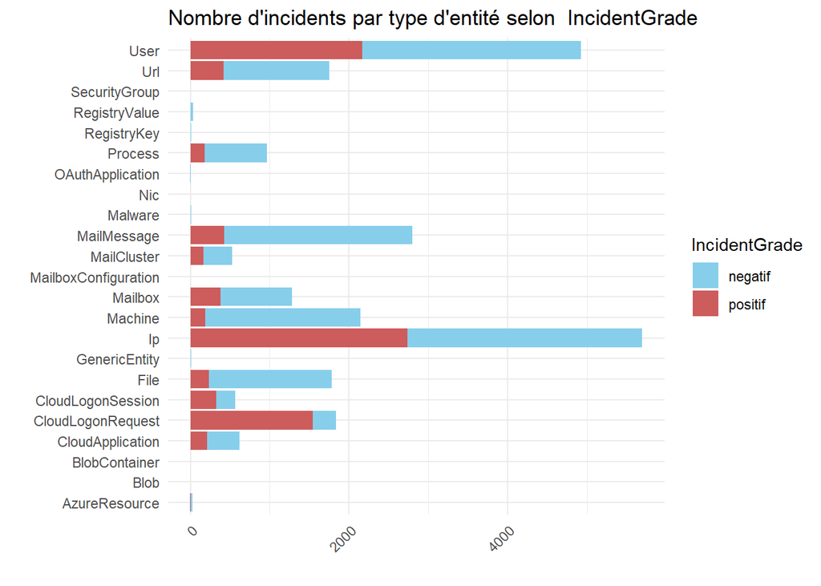

```r
ggplot(df, aes(x = EntityType, fill = IncidentGrade)) +
  geom_bar() +
  labs(
    title = "Nombre d'incidents par type d'entité selon  IncidentGrade",
    x = " ",
    y = " "
  ) +
  theme_minimal() +
  scale_fill_manual(values = c("negatif" ="skyblue" , "positif" ="indianred" ))  +
  theme(axis.text.x = element_text(angle = 45, hjust = 1)) +
  coord_flip()
```

**interpretation**

Les entités les plus affectées sont Ip, Machine, User, etMailMessage,ces entités sont les plus exposées aux incidents de sécurité et nécessairement une surveillance renforcée.

*IncidentGrade* est négatif(bleu) certaines entités ont un grand nombre d’incidents classés comme négatifs ( negatif en bleu) comme Ip, MailMessage, et Machine ce qui peut indiquer quil ya trop de fausses alertes,des règles de détection trop sensibles oubien un filtrage inadéquat des menaces réelles .

Certaines entités ont beaucoup d’incidents négatifs mais peu de positifs ( OAuthApplication, Process, CloudApplication) ce qui indique que ces entités sont moins susceptibles d’être réellement compromises ou que les règles de détection sont mal calibrées pour elles.

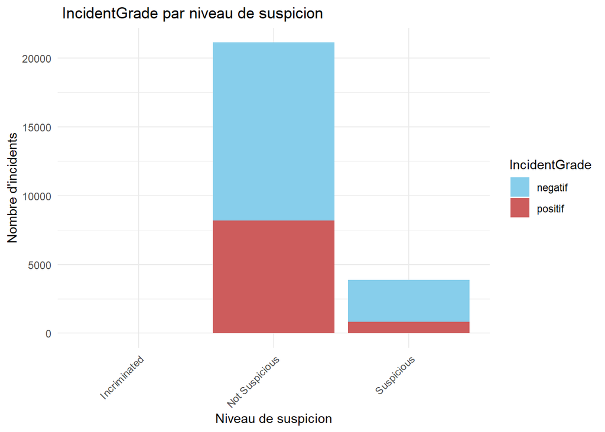

```r
ggplot(df, aes(x = SuspicionLevel, fill = IncidentGrade)) +
  geom_bar() +
  labs(
    title = " IncidentGrade par niveau de suspicion",
    x = "Niveau de suspicion",
    y = "Nombre d'incidents"
  ) +
  theme_minimal() +
  scale_fill_manual(values = c("negatif" ="skyblue" , "positif" ="indianred"))  +
  theme(axis.text.x = element_text(angle = 45, hjust = 1))
```

**interpretation**

La catégorie *Not Suspicious* représente l’écrasante majorité des incidents cela signifie que la plupart des alertes générées ne sont pas considérées comme suspectes. En gros le système de détection identifie beaucoup d’incidents mais les juge non suspects .

La catégorie *“Incriminated”* n’a pas de données visibles dans le graphique, ce qui suggère soit une absence de cas, soit un nombre très faible.

*IncidentGrade* est positif(rouge) : On observe une proportion importante d’incidents positifs dans *Not Suspicious* ce qui signifie que les menaces réelles sont classées comme «non suspectes»

*Suspicious* contient relativement peu d’incidents la plupart des incidents dans cette catégorie sont des incidents négatifs ( negatif) , ce qui signifie que le modèle considère rarement des événements comme véritablement suspects. Cela peut indiquer que les seuils de suspicion sont trop stricts et n’identifient pas assez d’attaques.

Il faut donc analyser les vrais incidents ( positif) dans *Not Suspicious* pour voir s’il ya des modèles d’attaques cachées. Comparer avec d’autres variables ( MitreTechniques, EntityType) pour identifier les entités les plus touchées dans chaque catégorie.

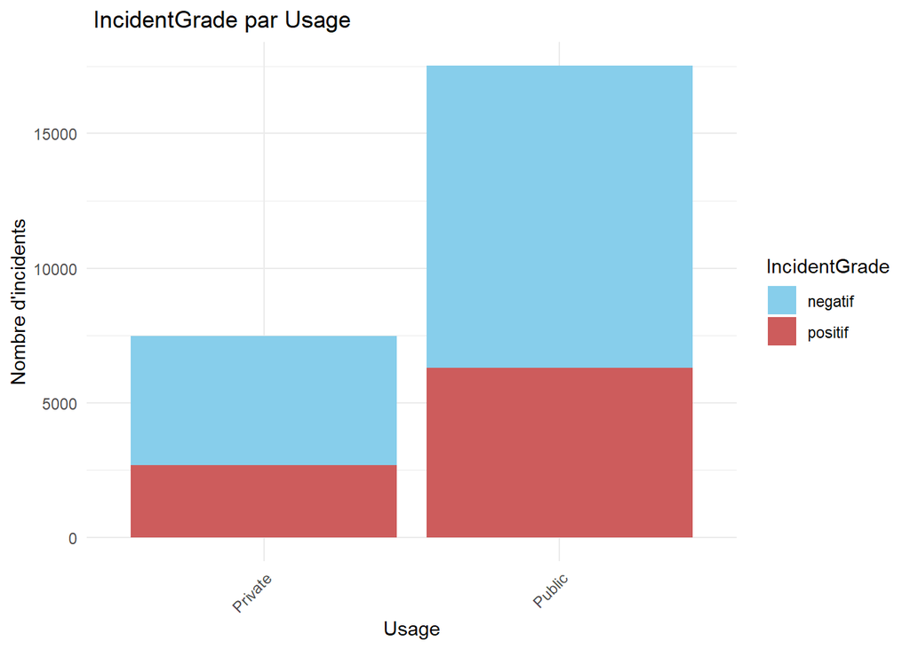

```r
ggplot(df, aes(x = Usage, fill = IncidentGrade)) +
  geom_bar() +
  labs(
    title = " IncidentGrade par Usage",
    x = "Usage",
    y = "Nombre d'incidents"
  ) +
  theme_minimal() +
  scale_fill_manual(values = c("negatif" ="skyblue" , "positif" ="indianred" ))  +
  theme(axis.text.x = element_text(angle = 45, hjust = 1))
```

**interpretation**

Les entités *Public* génèrent un nombre d’incidents nettement plus élevé que les entités Private. Cela signifie que les ressources publiques (ex. serveurs accessibles sur Internet, services cloud publics) sont beaucoup plus ciblées par des activités suspectes ou malveillantes.

*IncidentGrade* est positif(rouge):Le nombre d’incidents *positifs* est plus élevé dans *Public* que dans *Private*.Cela signifie que les attaques réussies sont plus fréquentes sur des ressources publiques car elle sont plus exposés et vulnérables.

Il faut donc analyser les incidents positifs en Public pour identifier les vecteurs d’attaque principaux et evaluer les écarts entre Public et Private afin de voir pourquoi les ressources privées ont-elles moins d’incidents confirmés.

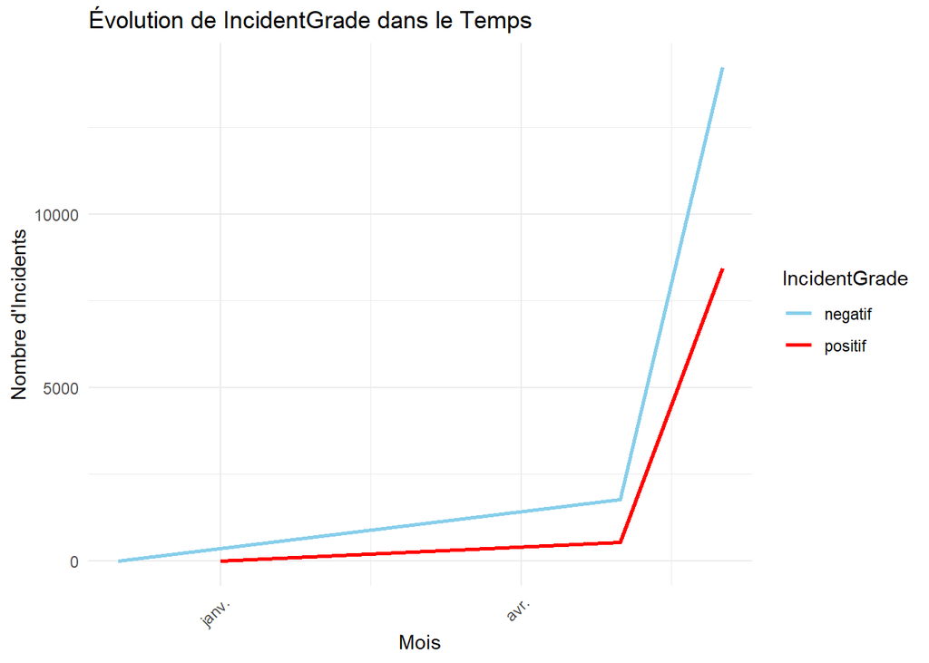

```r
incident_grade_monthly <- df %>%
  mutate(Month = floor_date(Timestamp, "month")) %>%
  group_by(Month, IncidentGrade) %>%
  summarise(Count = n(), .groups = 'drop')

# Graphique de l'évolution des IncidentGrade dans le temps

ggplot(incident_grade_monthly, aes(x = Month, y = Count, color = IncidentGrade)) +
  geom_line(size = 1) +
  labs(
    title = "Évolution de IncidentGrade dans le Temps",
    x = "Mois",
    y = "Nombre d'Incidents",
    color = "IncidentGrade"
  ) +
  theme_minimal() +
  scale_color_manual(values = c("negatif" = "skyblue", "positif" = "red")) +
  theme(axis.text.x = element_text(angle = 45, hjust = 1))
```

**interpretation** : On remarque que les déclarations d’incidents sont stables durant l’hivers. et le système ne capture que les transactions frauduleuse.

C’est en mai et Juin que se dégagent la majorité des signalements. Possible lien avec tous les mouvements qui se déroulent durant l’été ? c’est une question qu’il faudra explorer.

Faisons un zoom sur les fluxtuations pendant le mois de mai

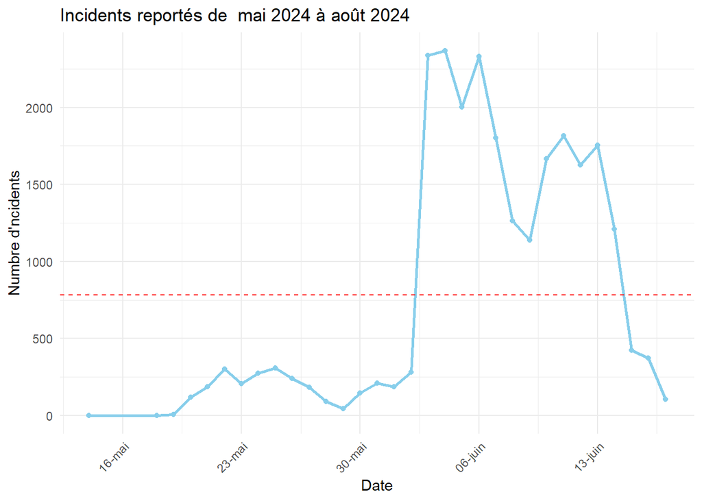

```r
start_date <- as.Date("2024-05-01")
end_date <- as.Date("2024-08-30")

filtered_data <- df %>%
  filter(Timestamp >= start_date & Timestamp <= end_date)

daily_counts <- filtered_data %>%
  group_by(Date = Timestamp) %>%
  summarise(Count = n(), .groups = "drop")

ggplot(daily_counts, aes(x = Date, y = Count)) +
  geom_line(color = "skyblue", size = 1) +
  geom_point(color = "skyblue") +
  labs(
    title = paste("Incidents reportés de ", format(start_date, "%B %Y"), "à", format(end_date, "%B %Y")),
    x = "Date",
    y = "Numbre d'ncidents"
  ) +
  theme_minimal() +
  theme(axis.text.x = element_text(angle = 45, hjust = 1)) +
  scale_x_date(date_breaks = "7 days", date_labels = "%d-%b") +
  geom_hline(yintercept = mean(daily_counts$Count), linetype = "dashed", color = "red")
```

**Interprétation** :

On observe une augmentation brutale autour du 1er juin , où le nombre d’incidents passe de moins de 500 à plus de 1500 en quelques jours du a des activité malveillante.Après le pic début juin, le nombre d’incidents commence à redescendre , avec une apparition notable entre le 6 et le 13 juin.Une tendance clairement baissière après le 13 juin ce qui es du surement a une réponse efficace des équipes de cybersécurité ou une résolution des problèmes détectés début juin. La ligne rouge indique la moyenne du nombre d’incidents sur la période .

Analysons les incidents entre le 1er et le 6 juin afin d’dentifier la cause du pic, vérifiions l’impact des contre-mesures après le 13 juin Ont-elles été efficaces ?

**Un approche serait de limiter notre étude aux incidents se produisant entre le 16 mai et le 13 juin, pour capter le flux de variation et optimiser le modèle. Mais nous n’allons pas le faire dans le cadre de ce travail.**

#### 2.2 Test d’hypothèse

H0 : la moyenne journalière d’incidents en juin est la même que pour tous les mois.

H1 : la moyenne journalière d’incidents en juin est supérieure.

$$\alpha = 0.05$$
*Conditions d’application du ttest:*

- les observations sont indépendantes, du fait que les jours sont indépendants
- On a plus de 30 observation –> la distribution est considérée comme normale
- homoscédasticité –> On le teste avec le test de Levene

```r
filtered_data <- filtered_data %>%
  mutate(Month = month(Timestamp, label = TRUE, abbr = FALSE))

monthly_avg <- daily_counts %>%
  mutate(Month = month(Date, label = TRUE, abbr = FALSE)) %>%
  group_by(Month) %>%
  summarise(DailyAvg = mean(Count), .groups = "drop")


ttest_data <- daily_counts %>%
  mutate(Month = month(Date, label = TRUE, abbr = FALSE),
         Period = ifelse(Month == "juin", "Juin", "Autres mois"))
ttest_data$Period <- factor(ttest_data$Period)

levene <- leveneTest(Count ~ Period, data = ttest_data)
 cat('p-value :' , levene$`Pr(>F)`[1])
```

```
## p-value : 0.000224716
```

*p-value 0.05* Donc les variances ne sont pas égales.

On va donc appliquer le test de Welch

```r
resultat = t.test(Count ~ Period, data = ttest_data, alternative = "less")
t_result <- t.test(Count ~ Period, data = ttest_data, alternative = "greater")

print(resultat)
```

```
##
##  Welch Two Sample t-test
##
## data:  Count by Period
## t = -6.0609, df = 16.659, p-value = 6.941e-06
## alternative hypothesis: true difference in means between group Autres mois and group Juin is less than 0
## 95 percent confidence interval:
##       -Inf -840.8018
## sample estimates:
## mean in group Autres mois        mean in group Juin
##                  154.3333                 1334.1765
```

**interprétation :** Le test de Welch a révélé une différence statistiquement significative entre le nombre d’incidents signalés en Juin et les autres mois (p < 0.05). En d’autres termes, les incidents de cybersécurité ont été significativement plus fréquents pendant le mois de juin par rapport aux autres mois de la période étudiée. Cette différence pourrait indiquer une tendance saisonnière ou une concentration d’événements liés à des facteurs spécifiques à cette période.

#### 2.3 Apprentisssage non supervisé.

#### Préparation de la base initiale

Dans cette session, nous allons dans un premier temps préparer les colonnes da le base des données au complet, par la suite nous batirons les différents modèles sur un échantillonage alléatoire de 25 000 observations pour accélérer les calculs.

Une fois le meilleur modèle trouvé, nous allons revenir sur la base des données de 4 millions d’observations le deployer.

Il ne sera pas necessaire par la suite de retirer les 25000 observation déjà vues par le modèle, par ce qu’elles représentent 0.6% de l’ensemble des observation, ce qui est négligeable.

Comptons le nombre de valeurs distinctes par colonnes pour déterminer le meilleur algorithme de conversion.

```r
data$SuspicionLevel[is.na(data$SuspicionLevel)] <- "Not Suspicious"
data$LastVerdict[is.na(data$LastVerdict)] <- "Pending Analysis"
data$MitreTechniques[is.na(data$MitreTechniques)] <- "Unknown"

data <- data %>%
  mutate(
    IncidentGrade = case_when(
      IncidentGrade == "BenignPositive" ~ "negatif",
      IncidentGrade == "FalsePositive" ~ "negatif",
      IncidentGrade == "TruePositive" ~ "positif"
    )
  )

distinct_counts <- c()

for (col in colnames(df)) {
  distinct_counts[col] <- length(unique(data[[col]]))
}

df_resume <- data.frame(
  Colonne = names(distinct_counts),
  Nb_Valeurs_Distinctes = as.integer(distinct_counts)
)
df_resume
```

```
##              Colonne Nb_Valeurs_Distinctes
## 1          Timestamp                482830
## 2         AlertTitle                 42265
## 3           Category                    19
## 4    MitreTechniques                   986
## 5      IncidentGrade                     2
## 6         EntityType                    29
## 7       EvidenceRole                     2
## 8             Sha256                 59446
## 9          IpAddress                173786
## 10               Url                 65600
## 11        AccountUpn                311996
## 12       AccountName                222314
## 13        DeviceName                 74791
## 14       RegistryKey                   995
## 15 RegistryValueName                   255
## 16 RegistryValueData                   492
## 17   ApplicationName                  1514
## 18          FileName                122200
## 19        FolderPath                 43970
## 20          OSFamily                     5
## 21         OSVersion                    43
## 22    SuspicionLevel                     3
## 23       LastVerdict                     5
## 24       CountryCode                   212
## 25             State                  1159
## 26              City                  6637
## 27             Usage                     2
```

Il y a trop des colonnes ayant énormément de valeurs distinctes, ce problème rend impossible l’annalyse PCA, puisque nous n’avons pas assez de ressources pour le faire.

Pour contourner le problème, on va faire un oneHot Encoder uniquement sur les colonnes ayant 10 ou moins de 10 valeurs distinctes.

Quant aux autres colonnes, on va faire un encodage des fréquences. Nous sommes consciens que ca va un peu biaiser le résultat, mais c’est le seul moyen de se faire une idée sur les variables avec les ressources en notre disposition.

```r
df_10_et_moins <- df_resume[df_resume$Nb_Valeurs_Distinctes <= 10, ]
df_plus_10     <- df_resume[df_resume$Nb_Valeurs_Distinctes > 10, ]

df_10_et_moins <- data[, df_10_et_moins$Colonne]
df_plus_10 <- data[,df_plus_10$Colonne]
```

Le colonnes ont énnormément de valeurs distinctes, le meilleur algorithme ici sera **embeddings**, mais nous n’avons pas acces aux super calculateurs pour la mettre en oeuvre.

Nous allons donc opter pour **l’encodage à laide des proportions** sur les colonnes ayant plus de 10 valeurs distinctes, et l’ Encodage One-Hot pour les autres colones.

```r
df_onehot <- dummy_cols(df_10_et_moins, remove_first_dummy = FALSE, remove_selected_columns = TRUE)
```

```r
# Fonction pour encoder les fréquences
encode_frequencies <- function(df) {
  df_encoded <- df  # c'est pour eviter d'ecraser df

  for (col in colnames(df)) {
    if (is.factor(df[[col]]) | is.character(df[[col]])) {
      freq_table <- table(df[[col]])  # Créer la table des fréquences
      df_encoded[[col]] <- as.integer(factor(df[[col]], levels = names(freq_table)))  # Encoder les fréquences
    }
  }

  return(df_encoded)
}

# Appliquer la fonction à ton dataframe
df_encoded <- encode_frequencies(df_plus_10)
```

```r
data_traite <- cbind(df_onehot, df_encoded)
data_traite <- data_traite[, sapply(data_traite, is.numeric)]

if ("IncidentGrade_negatif" %in% colnames(data_traite)) {
 data_traite <- subset(data_traite, select = -IncidentGrade_negatif)
 data_traite <- data_traite %>%
  rename(IncidentGrade = IncidentGrade_positif)
}


# Nettoyage des noms de colonnes pour enlever les espaces
names(data_traite) <- make.names(names(data_traite))
data_traite <- data_traite[sapply(data_traite, is.numeric)]
glimpse(data_traite)
```

```
## Rows: 4,147,992
## Columns: 35
## $ OSFamily                                                       <int> 5, 0, 5…
## $ IncidentGrade                                                  <int> 0, 0, 0…
## $ EvidenceRole_Impacted                                          <int> 1, 1, 0…
## $ EvidenceRole_Related                                           <int> 0, 0, 1…
## $ SuspicionLevel_                                                <int> 0, 0, 0…
## $ SuspicionLevel_Incriminated                                    <int> 0, 0, 0…
## $ SuspicionLevel_Suspicious                                      <int> 1, 1, 1…
## $ LastVerdict_                                                   <int> 0, 0, 0…
## $ LastVerdict_DomainPII_50d8b4a941c26b89482c94ab324b5a274f9ced66 <int> 0, 0, 0…
## $ LastVerdict_Malicious                                          <int> 0, 0, 0…
## $ LastVerdict_NoThreatsFound                                     <int> 0, 0, 0…
## $ LastVerdict_Suspicious                                         <int> 1, 1, 1…
## $ Usage_Private                                                  <int> 1, 0, 0…
```

[output cut: 22 more lines]

#### 2.3.1 Analyse par composantes principales

Comme annoncé, On va maintenant copier 25000 observations de façon aléatoire sur data_traité pour batir notre modèle par la suite

```r
set.seed(2025)
df_copie <- data_traite %>%
sample_n(25000)
```

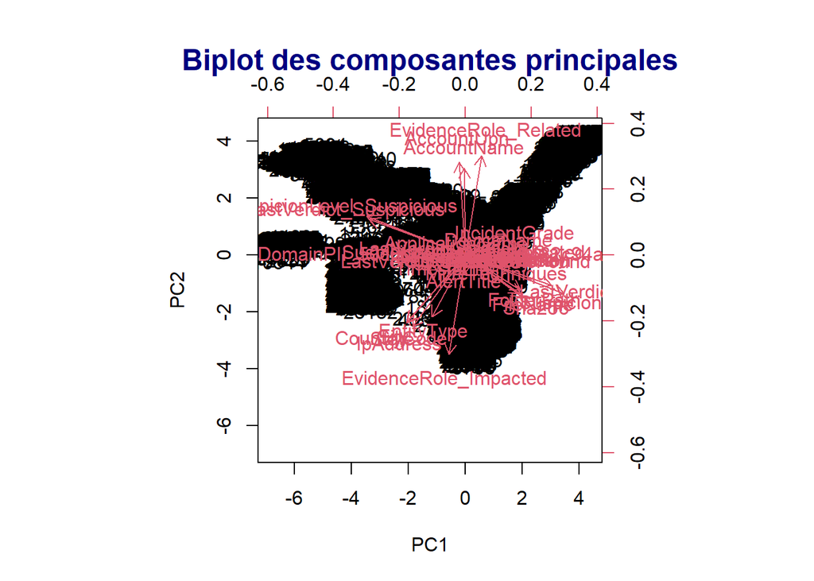

```r
pr.out <- prcomp(df_copie, scale = TRUE)
col_names <- colnames(df_copie)
pve <- summary(pr.out)$importance[2, ]

df_pve <- data.frame(
  Composante = 1:length(col_names),
  PVE = pr.out$sdev^2 / sum(pr.out$sdev^2),
  Colonne = col_names
)

 biplot(pr.out, scale = 0,
       main = "Biplot des composantes principales",
       cex.main = 1.5, col.main = "navy")
```

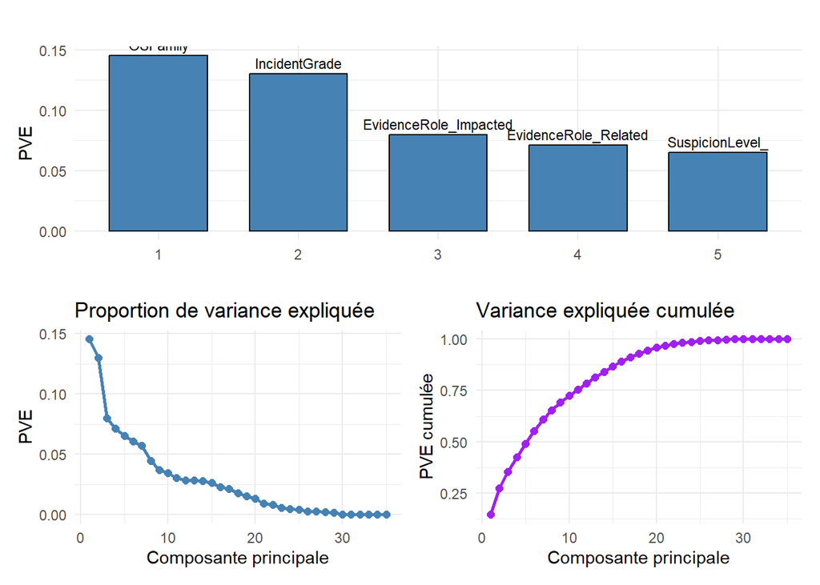

```r
pve <- summary(pr.out)$importance[2, ]


df_pve <- data.frame(
  Composante = 1:length(pve),
  PVE = pve,
  PVE_Cumulee = cumsum(pve)
)

col_names_5 <- colnames(df_copie)[1:5]
df_pve_5 <- data.frame(
  Composante = 1:length(col_names_5),
  PVE = pr.out$sdev[1:5]^2 / sum(pr.out$sdev^2),
  Colonne = col_names_5
)

p1 <- ggplot(df_pve_5, aes(x = factor(Composante), y = PVE)) +
  geom_bar(stat = "identity", fill = "steelblue", color = "black", width = 0.7) +
  geom_text(aes(label = Colonne), vjust = -0.5, color = "black", size = 3) +
  labs(title = " ", x = " ", y = "PVE") +
  theme_minimal()

p2 <- ggplot(df_pve, aes(x = Composante, y = PVE)) +
  geom_line(color = "steelblue", size = 1) +
  geom_point(color = "steelblue", size = 2) +
  labs(title = "Proportion de variance expliquée", x = "Composante principale", y = "PVE") +
  theme_minimal()


p3 <- ggplot(df_pve, aes(x = Composante, y = PVE_Cumulee)) +
  geom_line(color = "purple", size = 1) +
  geom_point(color = "purple", size = 2) +
  labs(title = "Variance expliquée cumulée", x = "Composante principale", y = "PVE cumulée") +
  theme_minimal()

p1/(p2+p3)
```

Avec 20 composantes principales, on est capable d’expliquer environ 95% de la variabilité des observations.

#### 2.3.2 : Clustering –> Méthode des k-means

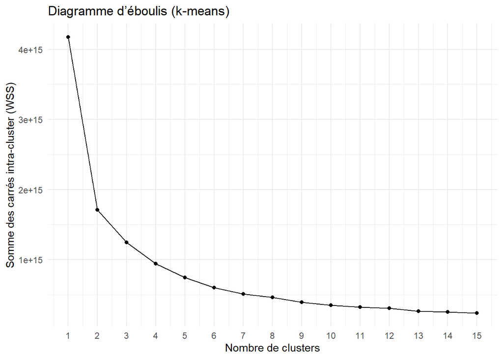

```r
pr.out <- prcomp(df_copie, scale. = TRUE)

set.seed(2025)
wss=c()
for (k in 1:15) {
  km <- kmeans(df_copie, centers = k, nstart = 20)
  wss[k] <- km$tot.withinss
}


df_wss <- data.frame(
  k = 1:15,
  WSS = wss
)


ggplot(df_wss, aes(x = k, y = WSS)) +
  geom_point() +
  geom_line() +
  scale_x_continuous(breaks = 1:15) +
  labs(
    title = "Diagramme d’éboulis (k-means)",
    x = "Nombre de clusters",
    y = "Somme des carrés intra-cluster (WSS)"
  ) +
  theme_minimal()
```

On voit que le coude se trouveentre 2 et 4, donc il est égal à 3. Ainsi, il est judicieux de diviser le set en 3 clusters.

```r
km.out <- kmeans(df_copie, 3, nstart = 30)
km.out$size
```

```
## [1]  8025 11605  5370
```

On ne peut pas visualiser les cluster à cause de la dimensionnalité. Mais nous pouvons quand meme remarquer qu’il y a trois groupes différents ayant pour tailles respectives 8025 observations, 11605 observations et 5370 observations.

Il est possibles que ces groupes correspondent aux transaction frauduleuses, non frauduleuses et pas encore classifiées (on ne peut pas encore se prononcer sur la cardinalité de chaque ensemble)

### 3. Modélisation prédictive.

#### 3.1 Régression logistique :

Cette partie est inspirée de la page suivante :

**https://stackoverflow.com/questions/53654193/how-to-generate-confusion-matrix-on-hold-out-sample-in-caret-xgbdart**

le code suivant a été inspiré de stack overflow. voici le lien vers la reférence :

**https://stackoverflow.com/questions/71516298/why-is-geom-roc-from-ggplot-vs-plot-roc-giving-such-drastic-difference-in-roc**

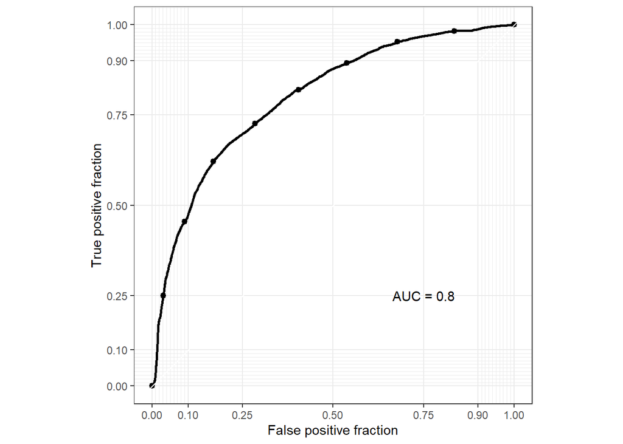

```r
pred_prob <- predict(meilleur_modele_logistique,  df_copie, type = "prob")[, 2]

roc_obj <- roc(df_copie$IncidentGrade, pred_prob,
               levels = levels(df_copie$IncidentGrade),
               direction = "<")

ggplot() +
  geom_roc(aes(m = pred_prob, d = as.numeric(df_copie$IncidentGrade)-1),
           labels = FALSE) +
  style_roc(theme = theme_minimal) +
  annotate("text", x = 0.75, y = 0.25,
           label = paste("AUC =", round(auc(roc_obj), 3)))+
  coord_equal()+
  style_roc()
```

**Interprétation** : La courbe est largement au dessus de la diagonale. Ce qui signifie que notre modèle est performent.

#### 3.2 Arbres de décision

```r
arbre <- tree(IncidentGrade ~ ., data = df_copie)

set.seed(2025)
cv_resultats <- cv.tree(arbre, FUN = prune.misclass)

print(cv_resultats)
```

```
## $size
## [1] 8 6 4 3 1
##
## $dev
## [1] 5039 5039 5275 5625 8997
##
## $k
## [1] -Inf    0  118  350 1686
##
## $method
## [1] "misclass"
##
## attr(,"class")
## [1] "prune"         "tree.sequence"
```

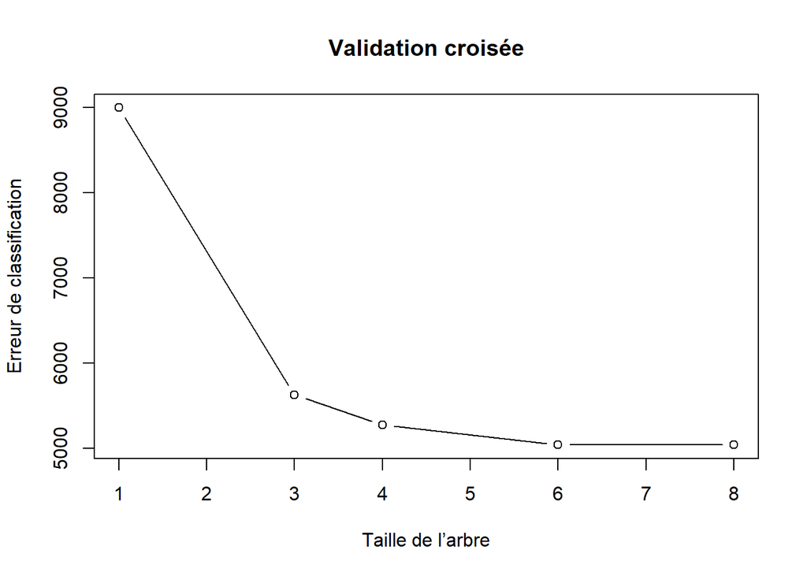

```r
plot(cv_resultats$size, cv_resultats$dev, type = "b",
     xlab = "Taille de l’arbre", ylab = "Erreur de classification",
     main = "Validation croisée")
```

```r
taille_opt <- cv_resultats$size[which.min(cv_resultats$dev)]

arbre_elague <- prune.misclass(arbre, best = taille_opt)


# Prédictions sur tout le jeu
pred <- predict(arbre_elague, newdata = df_copie, type = "class")

# Matrice de confusion et précision
confusion <- table(Prediction = pred, Réel = df_copie$IncidentGrade)
print(confusion)
```

```
##           Réel
## Prediction negatif positif
##    negatif   14875    3911
##    positif    1128    5086
```

```r
accuracy <- mean(pred == df_copie$IncidentGrade)

summary(arbre_elague)
```

```
##
## Classification tree:
## tree(formula = IncidentGrade ~ ., data = df_copie)
## Variables actually used in tree construction:
## [1] "AlertTitle"      "LastVerdict_"    "MitreTechniques" "Timestamp"
## [5] "Category"        "DeviceName"
## Number of terminal nodes:  8
## Residual mean deviance:  0.9207 = 23010 / 24990
## Misclassification error rate: 0.2016 = 5039 / 25000
```

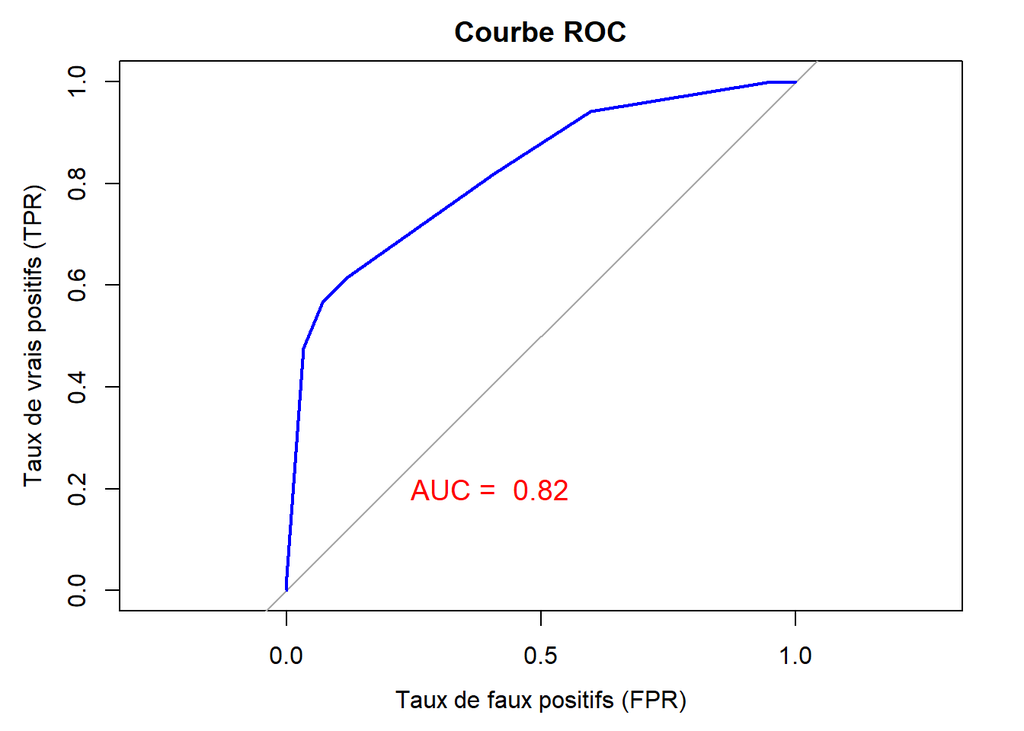

```r
#Aidé par ChatGPT
pred_prob <- predict(arbre_elague, newdata = df_copie, type = "vector")[, 2]

roc_curve <- roc(df_copie$IncidentGrade, pred_prob)
plot(roc_curve, legacy.axes = TRUE, main = "Courbe ROC", col = "blue", lwd = 2,
     xlab = "Taux de faux positifs (FPR)", ylab = "Taux de vrais positifs (TPR)")

auc_value <- auc(roc_curve)
text(0.6, 0.2, labels = paste("AUC = ", round(auc_value, 2)), col = "red", cex = 1.2)
```

### 4 Mise en production.

En comparant les courbes ROC des modèles ci-dessus définis, il ressort que l’arbre de décision élagué est le meilleur, avec un AUC de **0.82**

C’est donc ce modèle que nous allons déployer sur la vrai base de données

De façon plus précise, le modèle qui sera deployé en production est le suivant :

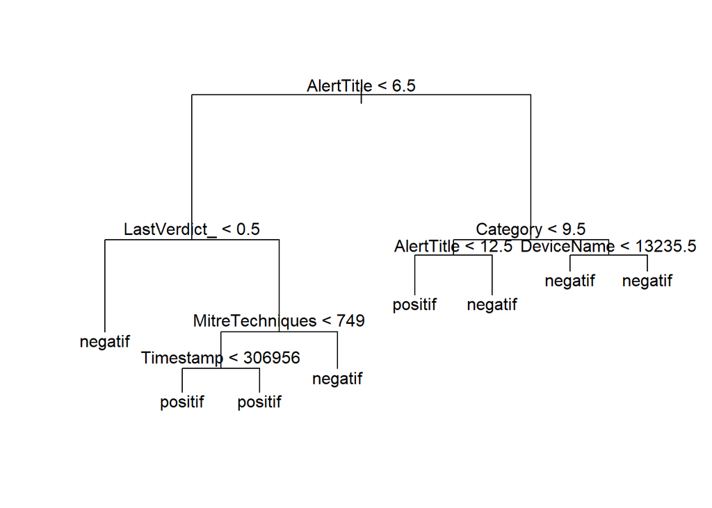

```r
plot(arbre_elague)
text(arbre_elague, pretty = 0)
```

```r
confusion <- table(Prediction = pred_vrai, Réel = data_traite$IncidentGrade)

# En pourcentages globaux
confusion_pourcentage <- round(100 * confusion / sum(confusion), 2)
print(confusion_pourcentage)
```

```
##           Réel
## Prediction negatif positif
##    negatif   59.55   15.78
##    positif    4.48   20.19
```

**Interpretation :**

```r
TN <- confusion_pourcentage["negatif", "negatif"]  # Vrai négatif
FP <- confusion_pourcentage["positif", "negatif"]  # Faux positif
FN <- confusion_pourcentage["negatif", "positif"]  # Faux négatif
TP <- confusion_pourcentage["positif", "positif"]  # Vrai positif
rappel = TP/(TP+FN)*100
precision = TP/(TP + FP)*100
accuracy <- TP + TN
```

Il reconnaît bien les transactions normales ( 59.55% sont bien classées comme normales).

Le taux de faux positifs ( 4.48%) est faible . Donc il ne crie pas “fraude” trop souvent quand ce n’en est pas une.

Finalement, on peut conclure qu’on a obtenu un Modèle prudent, qui évite de faussement d’accuser une transaction honnête, Mais trop conservateur, car il laisse passer presque la moitié des fraudes.

### 5. Conclusion

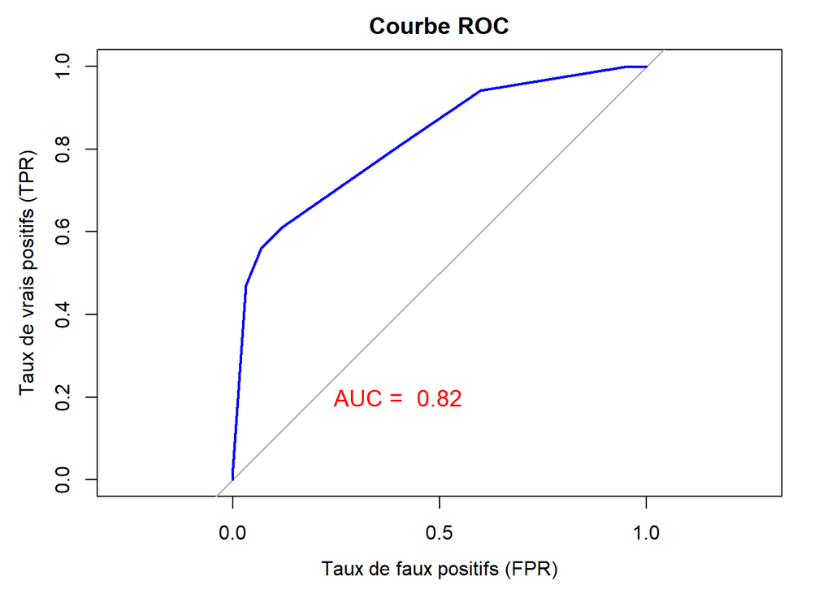

```r
dep_pred_prob <- predict(arbre_elague, newdata = data_traite, type = "vector")[, 2]

roc_curve <- roc(data_traite$IncidentGrade, dep_pred_prob)
plot(roc_curve, legacy.axes = TRUE, main = "Courbe ROC", col = "blue", lwd = 2,
     xlab = "Taux de faux positifs (FPR)", ylab = "Taux de vrais positifs (TPR)")

auc_value <- auc(roc_curve)
text(0.6, 0.2, labels = paste("AUC = ", round(auc_value, 2)), col = "red", cex = 1.2)
```

#### 5.2 Aller plus loin

Pour améliorer la qualité de ce travail, il serait important de se doter d’un super calculateur afin de pouvoir bénéficier des différentes ressources qui on conditionné certains de nos choix dans le cadre de ce travail.

On a aussi remarqué qu’il y a beaucoup de lignes de codes qui se repetaient et des opération qui étaient faites à la fois sur la base de données échantillonnée et sur la vrai base des données lors de la mise en production. Une bonne pratique sera aussi de créer les fonctions pour ces traitements et de les intégrer dans un pipeline afin d’automatiser les traitements dans le futur.

On devrait aussi raffiner d’avantage le modèle, car il laisse passer la moitié des fraudes, ce qui est très dangeureux. Car ne pas détecter une fraude est pire que faussement en suspecter une.

- une façon de régler ce problème :

Lors du calcul de la matrice de confusion, nous avons utilisé par défaut un seuil de classification (cutoff) fixé à 0,5. Toutefois, ce seuil pourrait être optimisé en utilisant l’indice de Youden, qui consiste à évaluer l’ensemble des seuils possibles afin de maximiser la somme de la sensibilité et de la spécificité. Cette approche permet de déterminer le cutoff optimal offrant le meilleur équilibre entre la détection des vrais positifs et la minimisation des faux positifs, c’est à dire **minimiser à la fois les faux positifs et les faux négatifs.**

**[Youden, W. J. (1950). Index for rating diagnostic tests. Cancer, 3(1), 32–35,**

**PMID: 15405679 DOI: 10.1002/1097-0142(1950)3:1<32::aid-cncr2820030106>3.0.co;2-3]**

- implementation avec r :

**https://stackoverflow.com/questions/73144637/ho-to-make-the-receiver-operating-characteristic-roc-and-identifying-the-youde**